# Post-termination effects

Sean Bloszies

## Table of Contents

Immediate Extractions (MBC, MBN, HWC, H2O)  
2-4wk Incubations (C and N Mineralization)  
Conclusions

## Intro

This document shows what changes about results if we look for main effects post-termination, rather than just looking at specific individual dates (either 1wk postkill, aka Postkill; or 4wk postkill, aka Midseason).

## Extraction data

First let's look at cover crop and/or kill effects combining the two dates after termination. What does the ANOVA show? (Here are the significant effects)

```
##          var               term sig
## 1   mbc_mgkg                 cc  **
## 2   mbc_mgkg               kill   *
## 3   mbc_mgkg               samp ***
## 5   mbc_mgkg              depth ***
## 7   mbc_mgkg            cc:samp   *
## 11  mbc_mgkg          samp:year ***
## 15  mbc_mgkg         year:depth ***
## 19  mbc_mgkg     kill:samp:year  **
## 65       mbn               samp  **
## 67       mbn              depth ***
## 73       mbn          samp:year ***
## 75       mbn         kill:depth  **
## 77       mbn         year:depth ***
## 84       mbn    kill:samp:depth   *
```

[output cut: 21 more lines]

### MBC

Here is the original MBC termination method effect means separation:

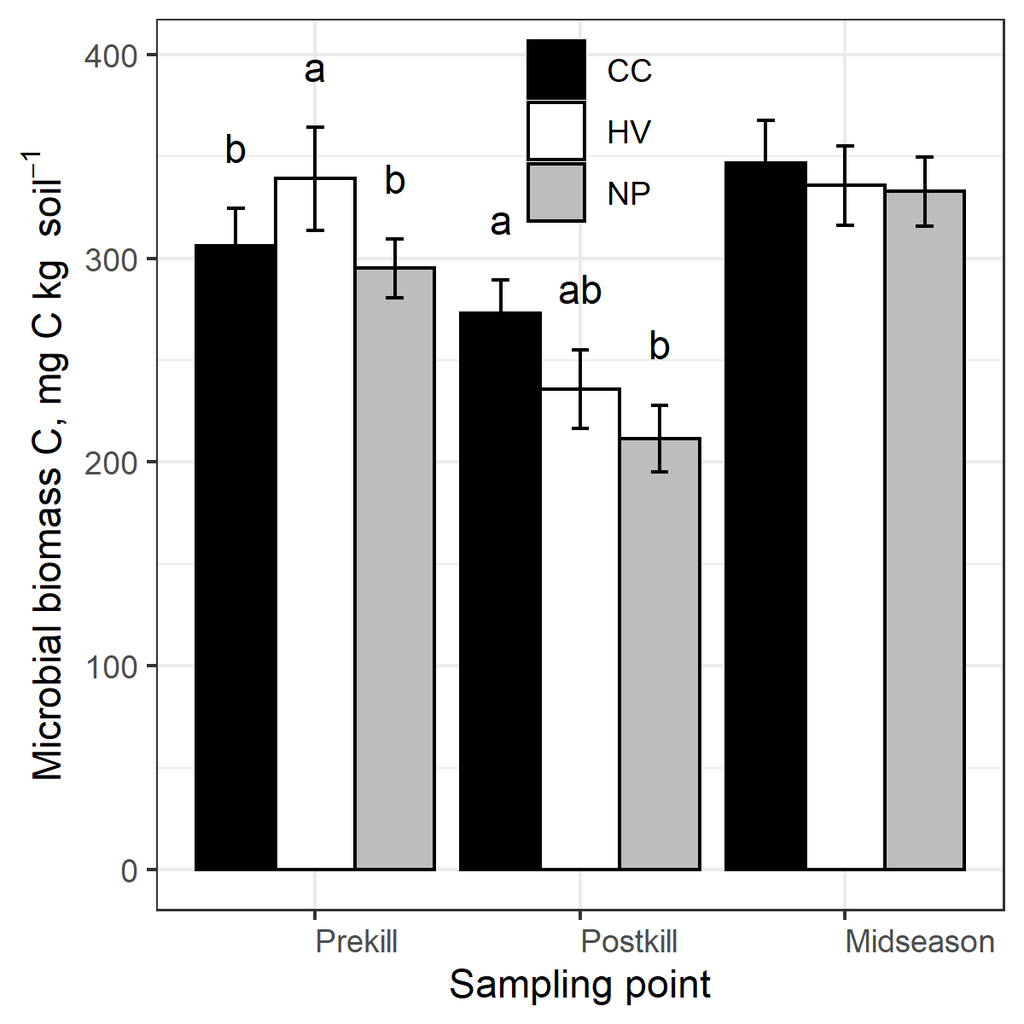

Figure 1

And since cover crop is significant on the ANOVA above, here is the a similar means separation but looking just at the last two date, over both dates.

```
##    cc lsmean   SE   df lower.CL upper.CL .group
## 2  cc    311 72.6 8780      168      453      a
## 3  hv    290 72.6 8755      147      432     ab
## 4 n00    270 72.6 8773      127      412      b
```

So it's the same as it was for Postkill in Figure 1 but significant over the two dates.

### Hot water extractable carbohydrates

For HWC, the new figure on the right tells a different story from the old on the left.

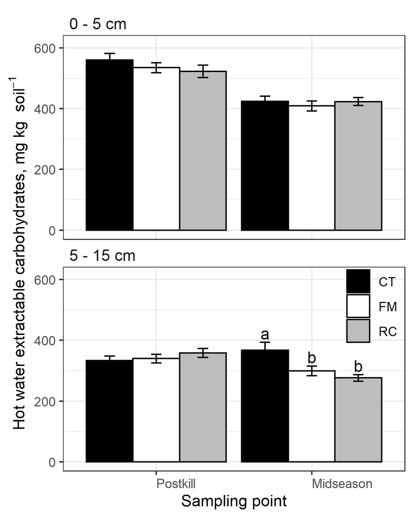

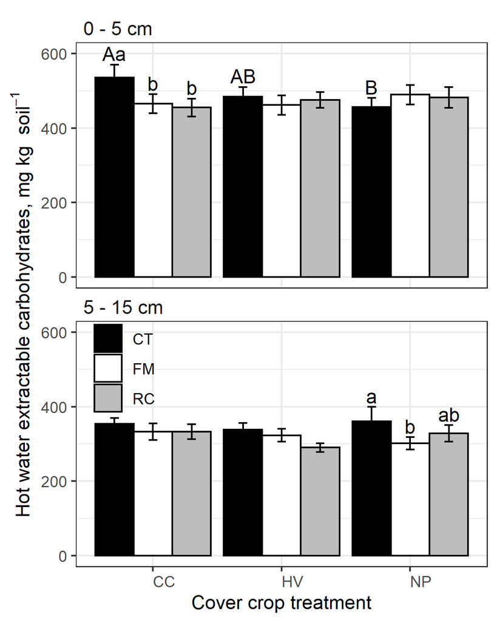

But the two figures don't conflict since the new on the right highlights the NP effect over both dates, whereas the old/left with the differences only at midseason just shows the kill effect ignoring cover crop, which is important because NP highlights that CT has higher HWC than the no-till methods lower in the profile. On the right, the clover (not vetch) elevates HWC in the surface soil, only when it is tilled in, maybe because the shoots are contributing to HWC. Or, tillage increases HWC, but only if CC is present. Kinda six and one have dozen. In the deeper soil, tillage increased HWC relative to FM, but *only* in NP so this means I will need to have rewritten the paper a little because I currently (as of Feb 2021) say in the paper that HWC was higher because of cover crop residue. So its more of a soil disruption thing.

### Soil moisture (gravimetric water content)

Next, there was a *year X kill X date X depth* interaction before.

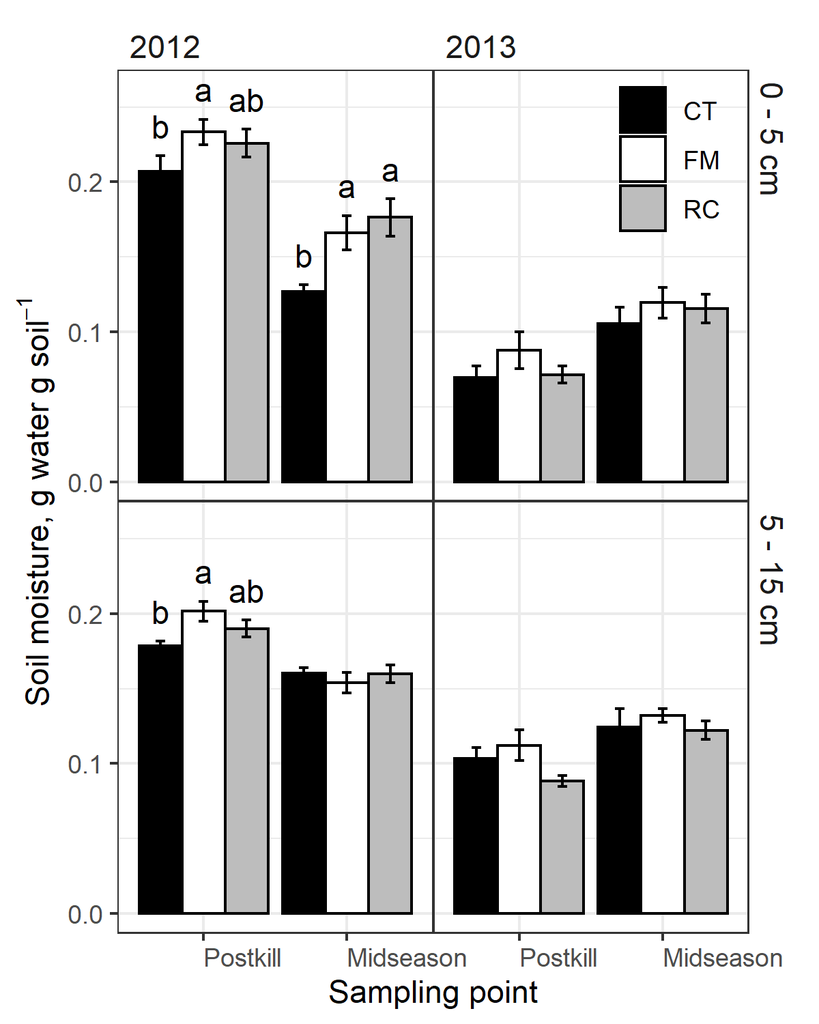

Is there anything if we pay attention to the lower order *year X kill X depth* interaction (i.e. ignore the date effect)? No, according to the ANOVA. So ther's not a new figure to contrast this one with.

What is new about this postkill main effects ANOVA? Two things: *cc X year* and *cc X kill X depth*

**First**, *cc X year* is pointing out that HV has higher moisture postkill than NP both years, and clover in 2012. This could be of pracitical importance if someone wants a cover crop that will conserve more moisture during the growing saeson. Old, all-dates figure on the left; New, no prekill figure on the right.

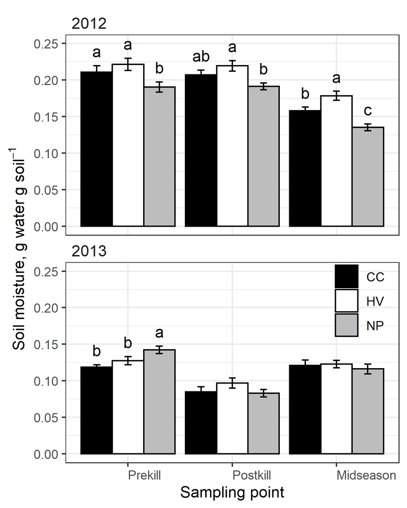

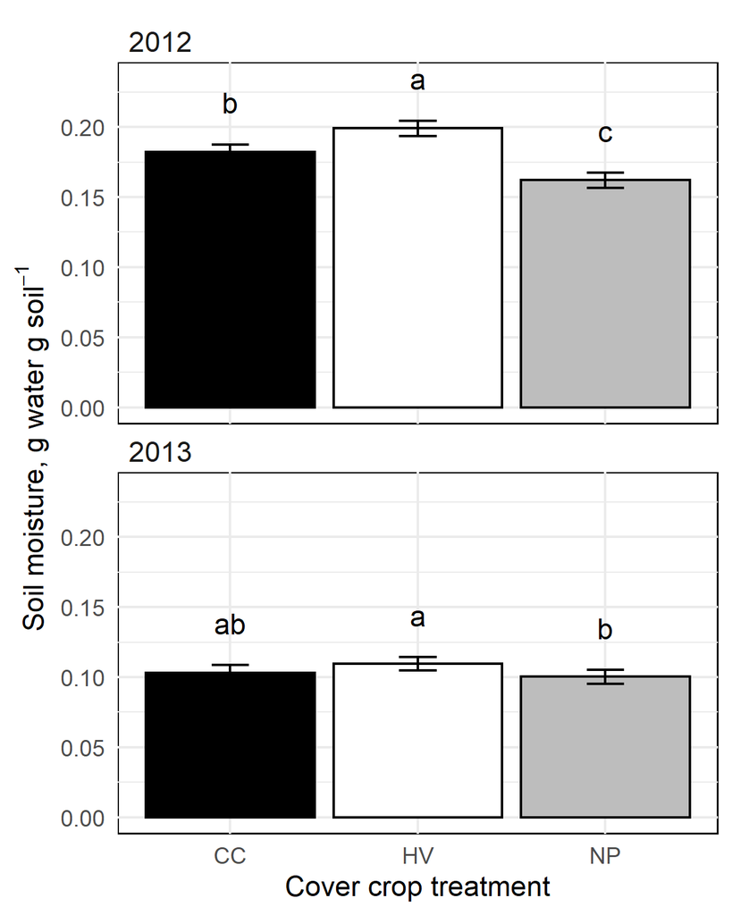

So the figure on the right shows that HV in both years does the same thing elevating moisture compared to the NP. But HV=CC and NP=CC in 2013.

**Second**, there is a *cc X kill X depth* from the ANOVA. There's not a figure or table from before excluding pre-kill to compare this to since there wasn't any *cc X kill* interactions.

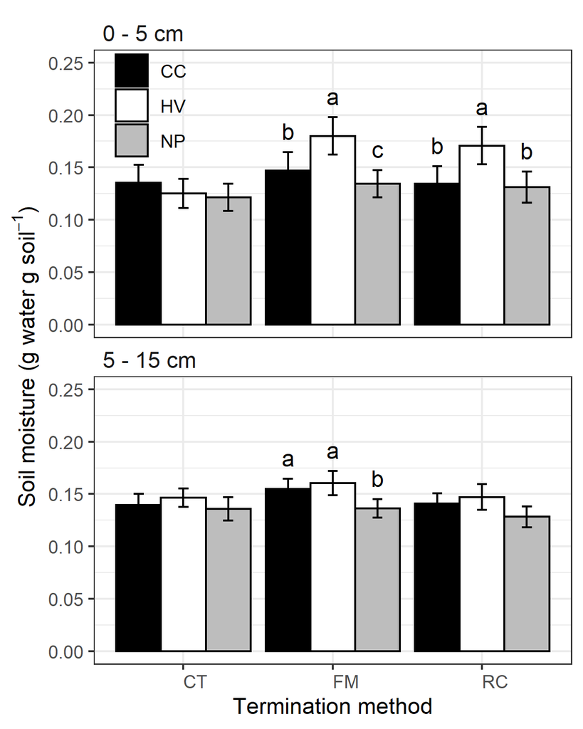

New

The closest thing to this is the year X date X cover figure (farther above on the left) that shows a cover effect, but only at certain times rather than in certain termination methods. Anyways this kind of contradicts the *cc X year* effect above so we should probably disregard the former.

With all the soil H2O stuff, it's only helpful in the paper if if backs up the other soil C & N and aggregation data, since this isn't really a study about soil water exactly.

## Incubations (C and N mineralization)

So there were some **cover crop** effects on mineralizable N and respiration before, right?

On the left is the original from the latest manuscrupt as of 2/11/20:..........And on the right is the new version as of 2/11/20:

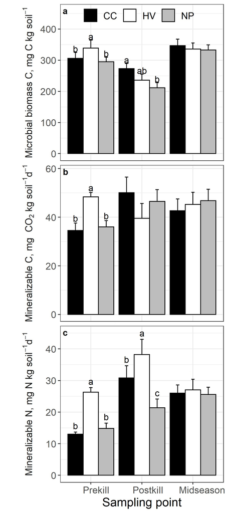

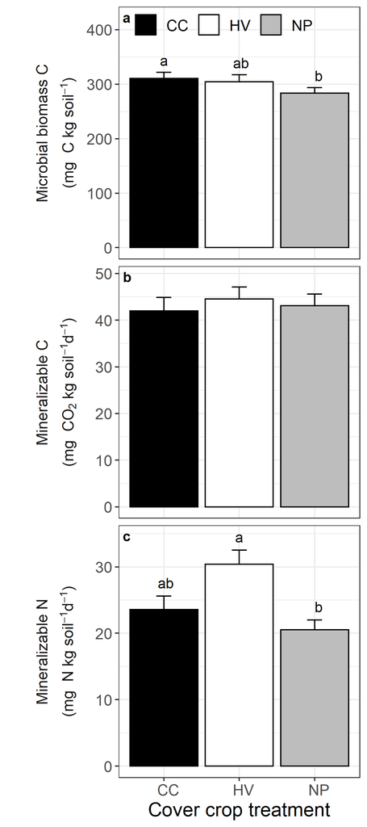

So these cover crop effects on either of the two dates are apparent as main effects post termination over both of the dates as well. I think concentrating on the main effects post kill doesn't change our interpretation really, since for respiration there is still no signifiant difference, and for mineralizable N the overall post-termination effect is mainly coming from the 1wk postkill date.

Now for the **termination effects** on incubation parameters.

On the left, the original from the latest manuscrupt as of 2/11/20:..........And here is the new version as of 2/11/20:

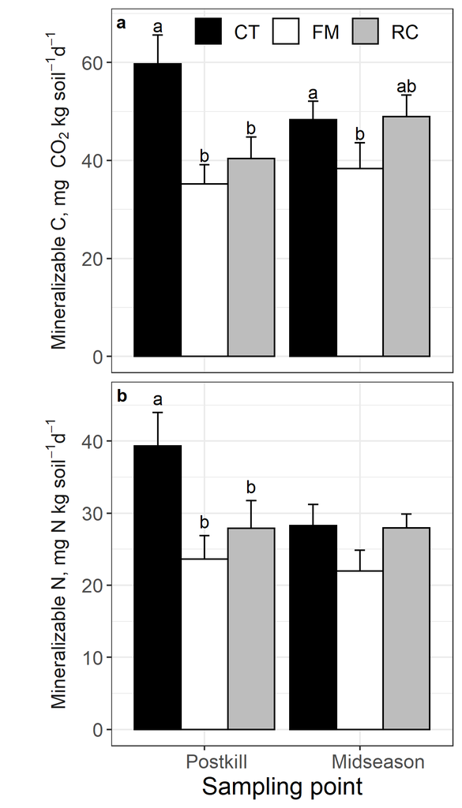

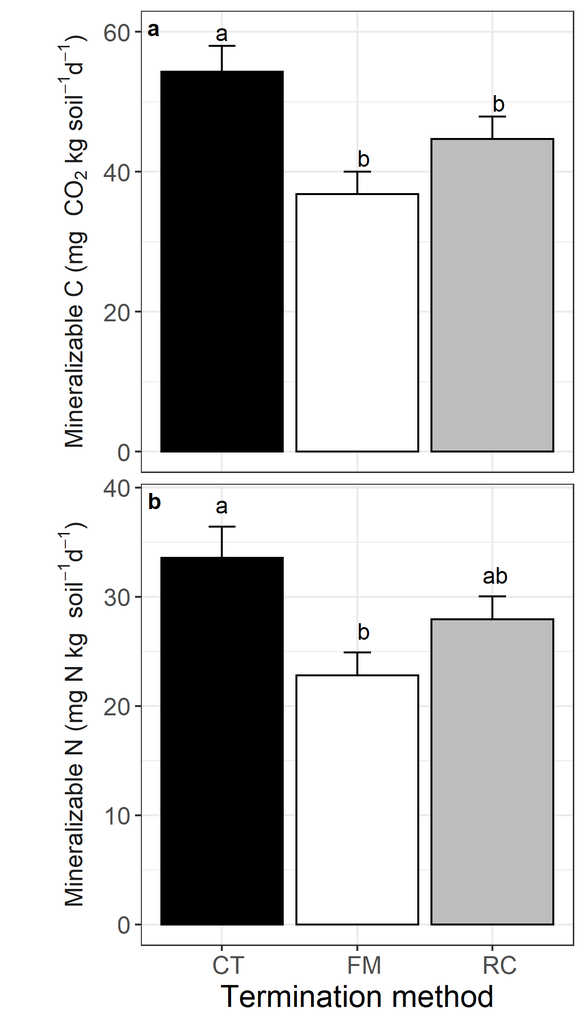

Again, I think concentrating on the main effects post kill doesn't change our interpretation here.

## Conclusions

- For **MBC**, **mineralizable N** and **minerlizable C**, post kill main effects doesn't add anything or highlight anything that wasn't significant in the old analysis.
- However, for **HWC**, at 0-5cm, clover has higher HWC than NP in the tilled plots, and tilled clover has higher HWC than non-tilled clover from 0-5 cm as well.
- For **soil moisture**, we now notice that HV soil is wetter than NP in 2013, whereas this was not significant before (HV was already wetter in 2012).
- However, **soil moisture** is higher in HV than CC or NP only in 0-5cm, non-tilled soil, and higher in HV only in mowed soil at 0-15cm.
- For aggregate **MWD**, this new analysis wouldnt've made a difference since there I only ever measured MWD once after termination each year anyways.